# Transformação de dados

Julio Trecenti

January 28, 2018

Nessa parte você aprenderá transformação de dados usando R

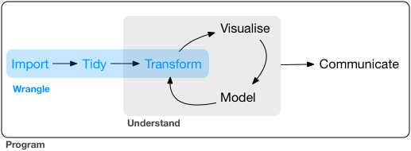

```r
knitr::include_graphics("imgs/wrangle.png")
```

Depois dessa parte, você se sentirá assim

[figure not shown]

Se você não praticar, você ficará assim

[figure not shown]

- Vamos utilizar uma base de dados de filmes do IMDB!
- Por isso, os memes dessa aula vêm do Choque de Cultura.
- Se você não conhece, parabéns! Você é uma sobrevivente da internet.

## Exercício 1: Setup

1.1. Abra o arquivo `manip-script.Rmd`, dentro da pasta `aula-manip/` 1.2. Encontre a linha onde está esse exercíicio. 1.3. Coloque o cursor abaixo do 1.5. 1.4. Digite `Ctrl+Alt+I`. Isso abrirá um *chunk*. - É dentro do chunk que você roda códigos R. - NÀO ESCREVA CÓDIGOS R FORA DOS CHUNKS 1.5. Rode `library(tidyverse)`

```r
library(tidyverse)
```

## O que é o tidyverse?

[figure not shown]

- Pacotes do R que facilitam a vida dos cientistas de dados.
- Integrados com o ciclo da ciência de dados.
- Construídos a partir de uma teoria comum e padronização.

Agora veremos dplyr e tidyr. Acesse https://tidyverse.org para detalhes sobre os demais.

## Exercício 2

2.1. Qual a diferença entre uma `matrix` e um `data.frame`?

```r
m <- matrix(1:10, ncol = 2)
m[1,1] <- "texto"
m
```

```
##      [,1]    [,2]
## [1,] "texto" "6"
## [2,] "2"     "7"
## [3,] "3"     "8"
## [4,] "4"     "9"
## [5,] "5"     "10"
```

```r
d <- data.frame(a = 1:5, b = 6:10)
d$a[1] <- "texto"
str(d)
```

```
## 'data.frame':    5 obs. of  2 variables:
##  $ a: chr  "texto" "2" "3" "4" ...
##  $ b: int  6 7 8 9 10
```

## O operador pipe `%>%`

[figure not shown]

[figure not shown]

Considere o seguinte exemplo:

```r
f <- function(x, y) x + y
x <- 1
y <- 2
```

As duas linhas abaixo são equivalentes:

```r
# caso você ainda não tenha carregado
library(tidyverse)

f(x, y)
```

```
## [1] 3
```

```r
x %>% f(y)
```

```
## [1] 3
```

### Receita de bolo

Tente entender o que é preciso fazer.

```r
esfrie(
  asse(
    coloque(
      bata(
        acrescente(
          recipiente(rep("farinha", 2), "água",
                     "fermento", "leite", "óleo"),
          "farinha", até = "macio"),
        duração = "3min"),
      lugar = "forma", tipo = "grande",
      untada = TRUE), duração = "50min"),
  "geladeira", "20min")
```

Desistiu? Agora veja como fica escrevendo com o `%>%`:

```r
recipiente(rep("farinha", 2), "água", "fermento", "leite", "óleo") %>%
  acrescente("farinha", até = "macio") %>%
  bata(duração = "3min") %>%
  coloque(lugar = "forma", tipo = "grande", untada = TRUE) %>%
  asse(duração = "50min") %>%
  esfrie("geladeira", "20min")
```

Agora o código realmente parece uma receita de bolo.

*Atalho*: Ctrl + Shift + M

Para mais informações sobre o `pipe` e exemplos de utilização, visite a página [Ceci n’est pas un pipe](http://cran.r-project.org/web/packages/magrittr/vignettes/magrittr.html).

## Pacotes `dplyr` e `tidyr`

Dados: vamos usar o IMDB - 2016

```r
imdb <- read_rds("data/dados_imdb.rds")
imdb
```

```
## # A tibble: 5,043 x 15
##    movie_title   title_year director_name  duration color genres   country
##    <chr>              <int> <chr>             <int> <chr> <chr>    <chr>
##  1 Avatar              2009 James Cameron       178 Color Action|~ USA
##  2 Pirates of t~       2007 Gore Verbinski      169 Color Action|~ USA
##  3 Spectre             2015 Sam Mendes          148 Color Action|~ UK
##  4 The Dark Kni~       2012 Christopher N~      164 Color Action|~ USA
##  5 Star Wars: E~         NA Doug Walker          NA <NA>  Documen~ <NA>
##  6 John Carter         2012 Andrew Stanton      132 Color Action|~ USA
##  7 Spider-Man 3        2007 Sam Raimi           156 Color Action|~ USA
##  8 Tangled             2010 Nathan Greno        100 Color Adventu~ USA
##  9 Avengers: Ag~       2015 Joss Whedon         141 Color Action|~ USA
## 10 Harry Potter~       2009 David Yates         153 Color Adventu~ UK
## # ... with 5,033 more rows, and 8 more variables: content_rating <chr>,
## #   budget <int>, gross <int>, imdb_score <dbl>,
## #   movie_facebook_likes <int>, actor_1_name <chr>, actor_2_name <chr>,
## #   actor_3_name <chr>
```

Outra forma de visualizar:

```r
glimpse(imdb)
## Observations: 5,043
## Variables: 15
## $ movie_title          <chr> "Avatar ", "Pirates of the Caribbean: At ...
## $ title_year           <int> 2009, 2007, 2015, 2012, NA, 2012, 2007, 2...
## $ director_name        <chr> "James Cameron", "Gore Verbinski", "Sam M...
## $ duration             <int> 178, 169, 148, 164, NA, 132, 156, 100, 14...
## $ color                <chr> "Color", "Color", "Color", "Color", NA, "...
## $ genres               <chr> "Action|Adventure|Fantasy|Sci-Fi", "Actio...
## $ country              <chr> "USA", "USA", "UK", "USA", NA, "USA", "US...
## $ content_rating       <chr> "PG-13", "PG-13", "PG-13", "PG-13", NA, "...
## $ budget               <int> 237000000, 300000000, 245000000, 25000000...
## $ gross                <int> 760505847, 309404152, 200074175, 44813064...
## $ imdb_score           <dbl> 7.9, 7.1, 6.8, 8.5, 7.1, 6.6, 6.2, 7.8, 7...
## $ movie_facebook_likes <int> 33000, 0, 85000, 164000, 0, 24000, 0, 290...
## $ actor_1_name         <chr> "CCH Pounder", "Johnny Depp", "Christoph ...
## $ actor_2_name         <chr> "Joel David Moore", "Orlando Bloom", "Ror...
## $ actor_3_name         <chr> "Wes Studi", "Jack Davenport", "Stephanie...
```

### As cinco funções principais do `dplyr`

- `select`: selecionar colunas
- `filter`: filtrar linhas
- `mutate`: criar colunas
- `arrange`: ordenar linhas
- `summarise`: sumarizar colunas

O `dplyr` pode ser considerado o pacote mais útil do R

[figure not shown]

```r
knitr::include_graphics("imgs/varias_razoes.jpg")
```

### Características do `dplyr`

- O *input* é sempre uma `tibble`, e o *output* é sempre uma `tibble`.
- No primeiro argumento colocamos a `tibble`, e nos outros argumentos colocamos o que queremos fazer.
- A utilização é facilitada com o emprego do operador `%>%`

### `arrange`

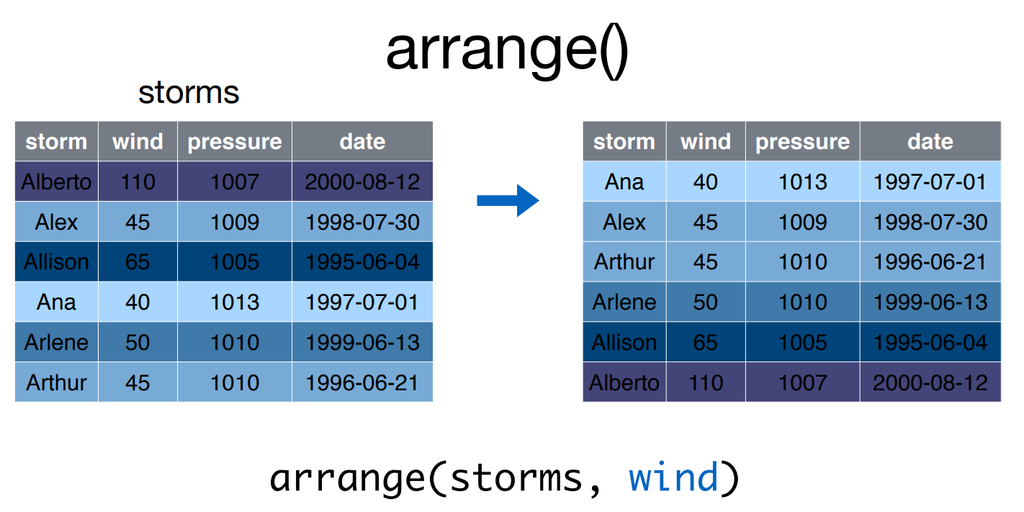

```r
knitr::include_graphics("imgs/arrange.png")
```

- Simplesmente ordena de acordo com as opções.
- Utilizar `desc()` para ordem decrescente.

```r
arrange(imdb, imdb_score)
```

```
## # A tibble: 5,043 x 15
##    movie_title   title_year director_name  duration color genres   country
##    <chr>              <int> <chr>             <int> <chr> <chr>    <chr>
##  1 Justin Biebe~       2011 Jon M. Chu          115 Color Documen~ USA
##  2 Foodfight!          2012 Lawrence Kasa~       91 Color Action|~ USA
##  3 Disaster Mov~       2008 Jason Friedbe~       88 Color Comedy   USA
##  4 Superbabies:~       2004 Bob Clark            88 Color Comedy|~ Germany
##  5 The Helix...~       2005 A. Raven Cruz        97 Color Action|~ USA
##  6 United Passi~       2014 Frédéric Aubu~      110 Color Drama|H~ France
##  7 Who's Your C~       2007 Don Michael P~       93 Color Comedy|~ USA
##  8 From Justin ~       2003 Robert Iscove        90 Color Comedy|~ USA
##  9 Glitter             2001 Vondie Curtis~      104 Color Drama|M~ USA
## 10 Crossover           2006 Preston A. Wh~       95 Color Action|~ USA
## # ... with 5,033 more rows, and 8 more variables: content_rating <chr>,
## #   budget <int>, gross <int>, imdb_score <dbl>,
## #   movie_facebook_likes <int>, actor_1_name <chr>, actor_2_name <chr>,
## #   actor_3_name <chr>
```

[figure not shown]

```r
knitr::include_graphics("imgs/justin-bieber-nsn-main.jpg")
```

Note que o código anterior é equivalente a

```r
imdb %>%
  arrange(imdb_score)
```

```
## # A tibble: 5,043 x 15
##    movie_title   title_year director_name  duration color genres   country
##    <chr>              <int> <chr>             <int> <chr> <chr>    <chr>
##  1 Justin Biebe~       2011 Jon M. Chu          115 Color Documen~ USA
##  2 Foodfight!          2012 Lawrence Kasa~       91 Color Action|~ USA
##  3 Disaster Mov~       2008 Jason Friedbe~       88 Color Comedy   USA
##  4 Superbabies:~       2004 Bob Clark            88 Color Comedy|~ Germany
##  5 The Helix...~       2005 A. Raven Cruz        97 Color Action|~ USA
##  6 United Passi~       2014 Frédéric Aubu~      110 Color Drama|H~ France
##  7 Who's Your C~       2007 Don Michael P~       93 Color Comedy|~ USA
##  8 From Justin ~       2003 Robert Iscove        90 Color Comedy|~ USA
##  9 Glitter             2001 Vondie Curtis~      104 Color Drama|M~ USA
## 10 Crossover           2006 Preston A. Wh~       95 Color Action|~ USA
## # ... with 5,033 more rows, and 8 more variables: content_rating <chr>,
## #   budget <int>, gross <int>, imdb_score <dbl>,
## #   movie_facebook_likes <int>, actor_1_name <chr>, actor_2_name <chr>,
## #   actor_3_name <chr>
```

Exercício 3:

3.1. Quais são os 5 melhores filmes segundo o `imdb_score`? 3.2. Quais são os 3 filmes em preto e branco mais recentes? - Dica: use `title_year` e `color`

### `select`

Crédito das imagens: [Garret Grolemund](https://ucsb-bren.github.io/env-info/wk03_dplyr/wrangling-webinar.pdf)

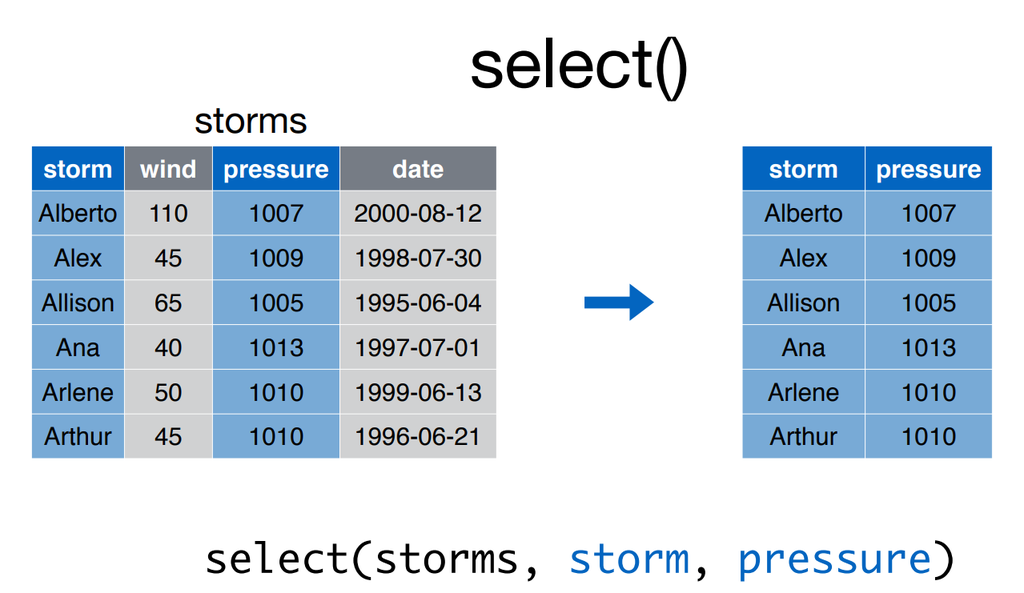

```r
knitr::include_graphics("imgs/select.png")
```

- Utilizar `starts_with(x)`, `contains(x)`, `matches(x)`, `one_of(x)`, etc.
- Possível colocar nomes, índices, e intervalos de variáveis com `:`.

```r
imdb %>%
  arrange(desc(imdb_score)) %>%
  select(movie_title, title_year, budget, gross)
```

```
## # A tibble: 5,043 x 4
##    movie_title                               title_year    budget    gross
##    <chr>                                          <int>     <int>    <int>
##  1 Towering Inferno                                  NA        NA  NA
##  2 The Shawshank Redemption                        1994  25000000   2.83e7
##  3 The Godfather                                   1972   6000000   1.35e8
##  4 Dekalog                                           NA        NA   4.47e5
##  5 Dekalog                                           NA        NA   4.47e5
##  6 Kickboxer: Vengeance                            2016  17000000  NA
##  7 The Dark Knight                                 2008 185000000   5.33e8
##  8 The Godfather: Part II                          1974  13000000   5.73e7
##  9 Fargo                                             NA        NA  NA
## 10 The Lord of the Rings: The Return of the~       2003  94000000   3.77e8
## # ... with 5,033 more rows
```

Exercício 4:

4.1. Selecione todas as colunas de atores. 4.2. Selecione todas as colunas que acabam com `_name`. 4.3. Selecione todas as colunas com `title`. 4.4. Selecione todas as colunas menos `movie_facebook_likes`. 4.5. Selecione todas as colunas entre `color` e `imdb_score`.

### `filter`

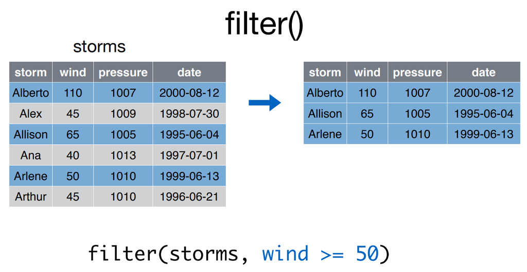

```r
knitr::include_graphics("imgs/filter.png")
```

- Use `,` ou `&` para “e” e `|` para “ou”.
- Condições separadas por vírgulas é o mesmo que separar por `&`.

```r
imdb %>%
  arrange(desc(imdb_score)) %>%
  select(movie_title, title_year, imdb_score, budget, gross) %>%
  filter(!is.na(title_year), !is.na(gross))
```

```
## # A tibble: 4,156 x 5
##    movie_title                      title_year imdb_score   budget   gross
##    <chr>                                 <int>      <dbl>    <int>   <int>
##  1 The Shawshank Redemption               1994       9.30   2.50e7  2.83e7
##  2 The Godfather                          1972       9.20   6.00e6  1.35e8
##  3 The Dark Knight                        2008       9.00   1.85e8  5.33e8
##  4 The Godfather: Part II                 1974       9.00   1.30e7  5.73e7
##  5 The Lord of the Rings: The Retu~       2003       8.90   9.40e7  3.77e8
##  6 Schindler's List                       1993       8.90   2.20e7  9.61e7
##  7 Pulp Fiction                           1994       8.90   8.00e6  1.08e8
##  8 The Good, the Bad and the Ugly         1966       8.90   1.20e6  6.10e6
##  9 Inception                              2010       8.80   1.60e8  2.93e8
## 10 The Lord of the Rings: The Fell~       2001       8.80   9.30e7  3.14e8
## # ... with 4,146 more rows
```

Exercício 5:

5.1. Filtre todos os filmes dos Estados Unidos 5.2. Filtre todos os filmes dos Estados Unidos ou do Reino unido - Dica: use `%in%` 5.3. Filtre todos os filmes com `imdb_score` acima de 9 e ordene por `imdb_score` de forma crescente 5.4. Filtre todos os filmes dos Estados Unidos com `budget` abaixo de 20.000 e ordene por `gross` de forma decrescente. Selecione as colunas `movie_title`, `title_year`, `gross` e `budget`. Verifique no Wikipédia o que raios ocorreu com o filme que ficou no topo.

```r
imdb %>%
  filter(country == "USA", budget < 20000) %>%
  arrange(desc(gross)) %>%
  select(movie_title, title_year, gross, budget)
```

```
## # A tibble: 13 x 4
##    movie_title           title_year     gross budget
##    <chr>                      <int>     <int>  <int>
##  1 Paranormal Activity         2007 107917283  15000
##  2 El Mariachi                 1992   2040920   7000
##  3 Tarnation                   2003    592014    218
##  4 Primer                      2004    424760   7000
##  5 The Puffy Chair             2005    192467  15000
##  6 Pink Flamingos              1972    180483  10000
##  7 My Date with Drew           2004     85222   1100
##  8 Breaking Upwards            2009     76382  15000
##  9 Newlyweds                   2011      4584   9000
## 10 The Touch                   2007        NA  13000
## 11 The Ridges                  2011        NA  17350
## 12 The Mongol King             2005        NA   3250
## 13 A Plague So Pleasant        2013        NA   1400
```

### `mutate`

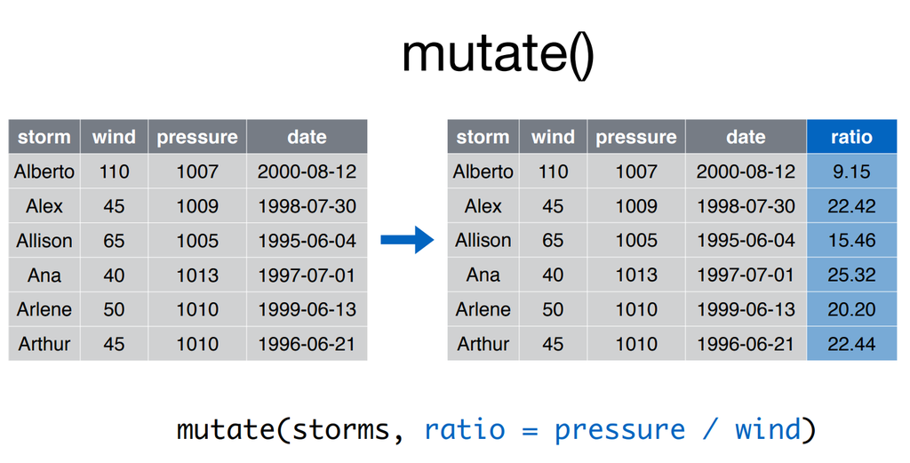

```r
knitr::include_graphics("imgs/mutate.png")
```

- Aceita várias novas colunas iterativamente.
- Novas variáveis devem ter o mesmo `length` que o `nrow` do bd original ou `1`.

```r
imdb %>%
  select(movie_title, director_name, title_year, imdb_score, budget, gross) %>%
  filter(!is.na(title_year), !is.na(gross)) %>%
  mutate(razao = gross / budget) %>%
  arrange(desc(razao))
```

```
## # A tibble: 4,156 x 7
##    movie_title    director_name  title_year imdb_score budget  gross razao
##    <chr>          <chr>               <int>      <dbl>  <int>  <int> <dbl>
##  1 Paranormal Ac~ Oren Peli            2007       6.30  15000 1.08e8  7194
##  2 Tarnation      Jonathan Caou~       2003       7.20    218 5.92e5  2716
##  3 The Blair Wit~ Daniel Myrick        1999       6.40  60000 1.41e8  2342
##  4 The Brothers ~ Edward Burns         1995       6.60  25000 1.02e7   410
##  5 The Texas Cha~ Tobe Hooper          1974       7.50  83532 3.09e7   369
##  6 The Texas Cha~ Tobe Hooper          1974       7.50  83532 3.09e7   369
##  7 El Mariachi    Robert Rodrig~       1992       6.90   7000 2.04e6   292
##  8 The Gallows    Travis Cluff         2015       4.20 100000 2.28e7   228
##  9 Super Size Me  Morgan Spurlo~       2004       7.30  65000 1.15e7   177
## 10 Halloween      John Carpenter       1978       7.90 300000 4.70e7   157
## # ... with 4,146 more rows
```

Exercício 6:

6.1. Qual é o filme menos rentável? 6.2. Nova métrica a. Retire filmes com razão acima de 100. b. Coloque a razão de `gross` e `budget` no intervalo [0,1]. c. Crie um novo índice obtido pela multiplicação de `imdb_score` e a `razao` padronizada. d. Qual é o melhor filme segundo esse índice?

### summarise

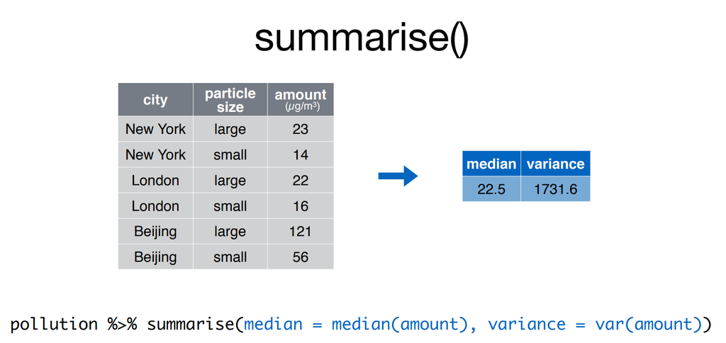

```r
knitr::include_graphics("imgs/summarise.png")
```

- Retorna um vetor de tamanho `1` a partir de uma conta com as variáveis.
- Geralmente é utilizado em conjunto com `group_by()`.
- Algumas funções importantes: `n()`, `n_distinct()`.

Melhores diretores com 5 ou mais filmes:

```r
imdb %>%
  select(movie_title, director_name, title_year, imdb_score, budget, gross) %>%
  group_by(director_name) %>%
  summarise(n = n(), nota_media = mean(imdb_score, na.rm = TRUE)) %>%
  filter(n >= 5) %>%
  arrange(desc(nota_media))
```

```
## # A tibble: 227 x 3
##    director_name             n nota_media
##    <chr>                 <int>      <dbl>
##  1 Christopher Nolan         8       8.43
##  2 Quentin Tarantino         8       8.20
##  3 Frank Capra               5       8.06
##  4 Stanley Kubrick           7       8.00
##  5 James Cameron             7       7.91
##  6 Alejandro G. Iñárritu     6       7.78
##  7 Fred Zinnemann            5       7.76
##  8 David Fincher            10       7.75
##  9 Peter Jackson            12       7.68
## 10 Martin Scorsese          20       7.66
## # ... with 217 more rows
```

Exercício 7:

7.1. Quais diretores tem maior soma, média e mediana de `gross`? 7.2. Qual a combinação de gêneros mais comum? Dica: use `count()`

## `tidyr`

- Até agora, estudamos os principais ferramentas de transformação de dados do `dplyr`.
- Agora vamos aumentar nosso toolkit com `tidyr`
- O `dplyr` está para o `tidyr` assim como tesoura/cola está para um alicate/martelo.
- Enquanto o `dplyr` faz recortes na base (com `filter()`e `select()`) e adições simples (`mutate()`, `summarise()`), o `tidyr` mexe no **formato** da tabela (`gather()`, `spread()`) e faz modificações menos triviais.
- As funções do `tidyr` geralmente vêm em pares com seus inversos:
  - `gather()` e `spread()`,
  - `nest()` e `unnest()`,
  - `separate()` e `unite()`

### `unite` e `separate`

- `unite` junta duas ou mais colunas usando algum separador (`_`, por exemplo).
- `separate` faz o inverso de `unite`, e uma coluna em várias usando um separador.

```r
imdb %>%
  separate(genres, c("tipo1", "tipo2", "tipo3"), sep = "\\|",
           fill = "right", extra = "merge")
```

```
## # A tibble: 5,043 x 17
##    movie_title  title_year director_name  duration color tipo1 tipo2 tipo3
##    <chr>             <int> <chr>             <int> <chr> <chr> <chr> <chr>
##  1 Avatar             2009 James Cameron       178 Color Acti~ Adve~ Fant~
##  2 Pirates of ~       2007 Gore Verbinski      169 Color Acti~ Adve~ Fant~
##  3 Spectre            2015 Sam Mendes          148 Color Acti~ Adve~ Thri~
##  4 The Dark Kn~       2012 Christopher N~      164 Color Acti~ Thri~ <NA>
##  5 Star Wars: ~         NA Doug Walker          NA <NA>  Docu~ <NA>  <NA>
##  6 John Carter        2012 Andrew Stanton      132 Color Acti~ Adve~ Sci-~
##  7 Spider-Man ~       2007 Sam Raimi           156 Color Acti~ Adve~ Roma~
##  8 Tangled            2010 Nathan Greno        100 Color Adve~ Anim~ Come~
##  9 Avengers: A~       2015 Joss Whedon         141 Color Acti~ Adve~ Sci-~
## 10 Harry Potte~       2009 David Yates         153 Color Adve~ Fami~ Fant~
## # ... with 5,033 more rows, and 9 more variables: country <chr>,
## #   content_rating <chr>, budget <int>, gross <int>, imdb_score <dbl>,
## #   movie_facebook_likes <int>, actor_1_name <chr>, actor_2_name <chr>,
## #   actor_3_name <chr>
```

Exercício 8:

8.1. Dentre os diretores, qual o primeiro nome mais comum?

### gather e spread

- `gather()` empilha o banco de dados

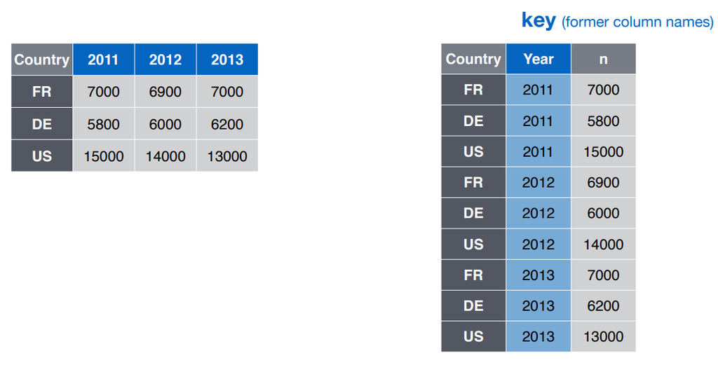

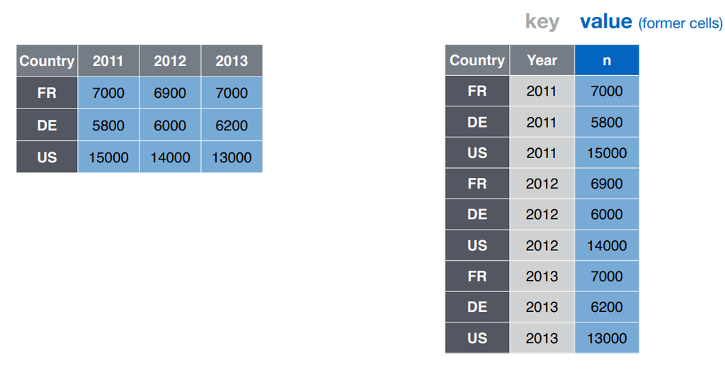

```r
knitr::include_graphics(c("imgs/gather1.png", "imgs/gather2.png"))
```

Exemplo: ator mais frequente

```r
gathered <- imdb %>%
  select(movie_title, title_year, starts_with("actor")) %>%
  gather(tipo_ator, nome_ator, starts_with("actor"))

gathered
```

```
## # A tibble: 15,129 x 4
##    movie_title                        title_year tipo_ator   nome_ator
##    <chr>                                   <int> <chr>       <chr>
##  1 Avatar                                   2009 actor_1_na~ CCH Pounder
##  2 Pirates of the Caribbean: At Worl~       2007 actor_1_na~ Johnny Depp
##  3 Spectre                                  2015 actor_1_na~ Christoph Wa~
##  4 The Dark Knight Rises                    2012 actor_1_na~ Tom Hardy
##  5 Star Wars: Episode VII - The Forc~         NA actor_1_na~ Doug Walker
##  6 John Carter                              2012 actor_1_na~ Daryl Sabara
##  7 Spider-Man 3                             2007 actor_1_na~ J.K. Simmons
##  8 Tangled                                  2010 actor_1_na~ Brad Garrett
##  9 Avengers: Age of Ultron                  2015 actor_1_na~ Chris Hemswo~
## 10 Harry Potter and the Half-Blood P~       2009 actor_1_na~ Alan Rickman
## # ... with 15,119 more rows
```

```r
gathered %>%
  count(nome_ator, sort = TRUE)
```

```
## # A tibble: 6,256 x 2
##    nome_ator          n
##    <chr>          <int>
##  1 Robert De Niro    54
##  2 Morgan Freeman    47
##  3 <NA>              43
##  4 Johnny Depp       41
##  5 Bruce Willis      40
##  6 Matt Damon        38
##  7 Steve Buscemi     37
##  8 Bill Murray       34
##  9 Brad Pitt         34
## 10 Liam Neeson       34
## # ... with 6,246 more rows
```

[figure not shown]

```r
knitr::include_graphics("imgs/dificil3.jpg")
```

- `spread()` espalha uma variável nas colunas e preenche com outra variável

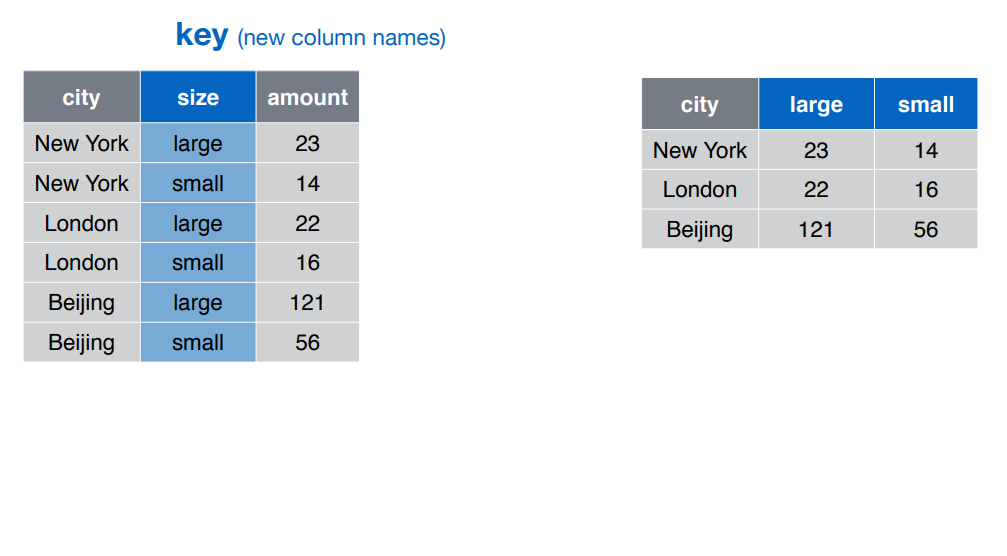

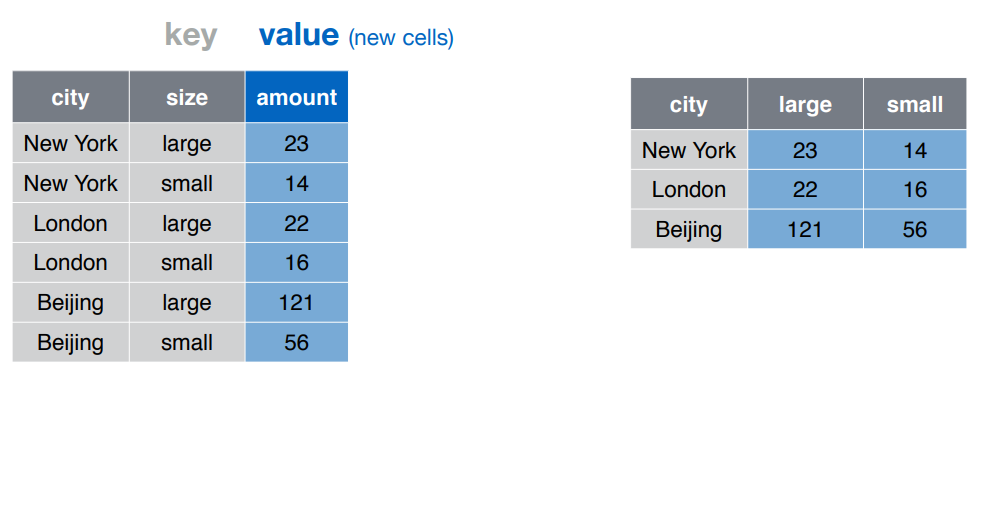

```r
knitr::include_graphics(c("imgs/spread1.png", "imgs/spread2.png"))
```

- spread É essencialmente a função inversa de `gather`

```r
imdb %>%
  select(movie_title, title_year, color, starts_with("actor")) %>%
  gather(tipo_ator, nome_ator, starts_with("actor")) %>%
  count(color, nome_ator, sort = TRUE) %>%
  filter(!is.na(color)) %>%
  spread(color, n, fill = 0) %>%
  arrange(desc(`Black and White`))
```

```
## # A tibble: 6,233 x 3
##    nome_ator           `Black and White` Color
##    <chr>                           <dbl> <dbl>
##  1 Montgomery Clift                 4.00  0
##  2 Anthony Hopkins                  3.00 27.0
##  3 Bob Hoskins                      3.00 13.0
##  4 Eva Green                        3.00  3.00
##  5 Liam Neeson                      3.00 31.0
##  6 Maggie Cheung                    3.00  1.00
##  7 Spencer Tracy                    3.00  1.00
##  8 Tony Chiu Wai Leung              3.00  2.00
##  9 Brad Pitt                        2.00 32.0
## 10 Brian O'Halloran                 2.00  0
## # ... with 6,223 more rows
```

Exercício 9:

9.1. Qual gênero é mais lucrativo? a. Separe os 7 primeiros gêneros b. Empilhe todos os gêneros c. Retire os `NA`s d. Obtenha quantidade, nota média e razão `gross` / `budget` para cada gênero e. Retire gêneros com menos de 100 filmes f. Ordene os gêneros pela razão de forma decrescente

### Duplicatas

Para retirar duplicatas, utilizar `distinct`. Ele considera apenas a primeira linha em que encontra um padrão para as combinações de variáveis escolhidas e descarta as demais.

```r
imdb %>%
  distinct(director_name)
```

```
## # A tibble: 2,399 x 1
##    director_name
##    <chr>
##  1 James Cameron
##  2 Gore Verbinski
##  3 Sam Mendes
##  4 Christopher Nolan
##  5 Doug Walker
##  6 Andrew Stanton
##  7 Sam Raimi
##  8 Nathan Greno
##  9 Joss Whedon
## 10 David Yates
## # ... with 2,389 more rows
```

Para manter as demais colunas, use `.keep_all=`:

```r
imdb %>%
  distinct(director_name, .keep_all = TRUE)
```

```
## # A tibble: 2,399 x 15
##    movie_title   title_year director_name  duration color genres   country
##    <chr>              <int> <chr>             <int> <chr> <chr>    <chr>
##  1 Avatar              2009 James Cameron       178 Color Action|~ USA
##  2 Pirates of t~       2007 Gore Verbinski      169 Color Action|~ USA
##  3 Spectre             2015 Sam Mendes          148 Color Action|~ UK
##  4 The Dark Kni~       2012 Christopher N~      164 Color Action|~ USA
##  5 Star Wars: E~         NA Doug Walker          NA <NA>  Documen~ <NA>
##  6 John Carter         2012 Andrew Stanton      132 Color Action|~ USA
##  7 Spider-Man 3        2007 Sam Raimi           156 Color Action|~ USA
##  8 Tangled             2010 Nathan Greno        100 Color Adventu~ USA
##  9 Avengers: Ag~       2015 Joss Whedon         141 Color Action|~ USA
## 10 Harry Potter~       2009 David Yates         153 Color Adventu~ UK
## # ... with 2,389 more rows, and 8 more variables: content_rating <chr>,
## #   budget <int>, gross <int>, imdb_score <dbl>,
## #   movie_facebook_likes <int>, actor_1_name <chr>, actor_2_name <chr>,
## #   actor_3_name <chr>
```

Use `janitor::get_dupes()` para averiguar os casos em que há repetição de combinações de colunas.

```r
library(janitor)
imdb %>%
  get_dupes(movie_title)
```

```
## # A tibble: 247 x 16
##    movie_title  dupe_count title_year director_name duration color genres
##    <chr>             <int>      <int> <chr>            <int> <chr> <chr>
##  1 20,000 Leag~          2       1954 Richard Flei~      127 Color Advent~
##  2 20,000 Leag~          2       1954 Richard Flei~      127 Color Advent~
##  3 A Dog's Bre~          2       2007 David Hewlett       88 Color Comedy
##  4 A Dog's Bre~          2       2007 David Hewlett       88 Color Comedy
##  5 A Nightmare~          2       1984 Wes Craven         101 Color Horror
##  6 A Nightmare~          2       1984 Wes Craven         101 Color Horror
##  7 A Woman, a ~          2       2009 Yimou Zhang         95 Color Comedy~
##  8 A Woman, a ~          2       2009 Yimou Zhang         95 Color Comedy~
##  9 Across the ~          2       2007 Julie Taymor       133 Color Drama|~
## 10 Across the ~          2       2007 Julie Taymor       133 Color Drama|~
## # ... with 237 more rows, and 9 more variables: country <chr>,
## #   content_rating <chr>, budget <int>, gross <int>, imdb_score <dbl>,
## #   movie_facebook_likes <int>, actor_1_name <chr>, actor_2_name <chr>,
## #   actor_3_name <chr>
```

Sim, tem duplicatas. E muitas! Talvez seja necessário realizar algumas análises novamente.

### Exercício 10

10.1. Dos estudos feitos anteriormente, quais são afetados por esse problema na base? 10.2. Como você arrumaria a base usando a função `distinct()`? 10.3. Refaça as análises afetadas com a base arrumada.

Para mais aplicações do `janitor`, ver [este blog post](http://curso-r.com/blog/2017/07/24/2017-07-24-janitor/).

### Extra: Joins

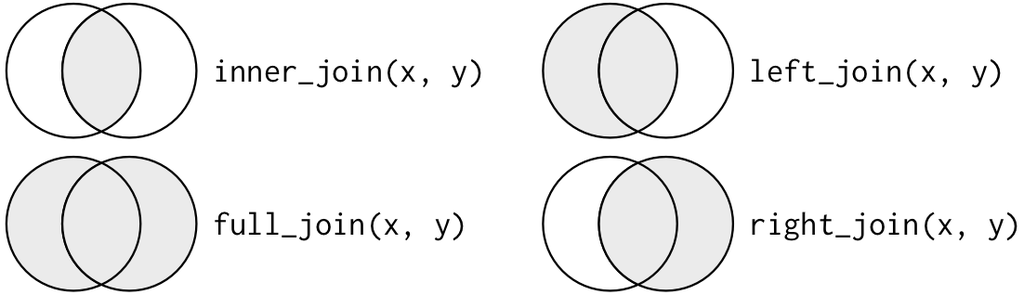

Para juntar tabelas, usar `inner_join`, `left_join`, `anti_join`, etc. O melhor material disso está em http://r4ds.had.co.nz/relational-data.html.

[figure not shown]

[figure not shown]

```r
knitr::include_graphics(c("imgs/info1.jpg", "imgs/info2.jpg"))
```

# Wrap-up

Hoje nós:

1. conhecemos o R, o RStudio e o R Markdown.
2. nos ambientamos no R aprendendo
   - operações
   - tipos de objeto
   - manipular vetores, listas e data frames
   - criar e usar funções
   - instalar e carregar pacotes
3. aprendemos a importar dados
   - funções do tipo `read_*()` e `write_*()`
   - tipos de input: texto, binário, banco de dados, lista
     - excel é do tipo lista!
4. aprendemos a usar o `%>%` e os cinco verbos do `dplyr`
   - `arrange()`, `select()`, `filter()`, `mutate()`, `summarise()`
5. conhecemos as funções inversíveis do tidyr
   - `gather()` e `spread()`
   - `unite()` e `separate()`
6. e uma miscelânea de coisas importantes
   - `distinct()` para retirar duplicatas.
   - `get_dupes()` do pacote `janitor`.

Na próxima vez, vamos visualizar dados com `ggplot2`!

[figure not shown]